# Amniote Longevity and Reproduction

Samuel Wolf

March 22, 2018

# Exploring the relationship of body size on lifestyle and productivity among Amniotes

## How does body-size affect the longevity of amniotes? Furthermore, how does female size and maturation correlate with egg size?

In this analysis I attempt to document and describe the relationship between the body sizes of select amniotes and their influence on the longevity of those animals. I continue this question in light of reproductive trends, and attempt to observe a pattern between female size and egg size in reptilian and avian classes. I also go one step further and try to answer whether there is a relationship between female maturity and egg size in reptiles and avian classes.

## Brief description of the methods

Using the Amniote life-history [database](http://www.esapubs.org/archive/ecol/E096/269/#data), I attempted to answer questions regarding amniote life-history. I analyzed the data using RStudio, and formatted my scripts with Rmarkdown.

```r
download.file("http://www.esapubs.org/archive/ecol/E096/269/Data_Files/Amniote_Database_Aug_2015.csv
", "./Data/Amniote_Database_Aug_2015.csv")
```

```r
# The code to read the data we just downloaded.
Amniote<-read.csv("./Data/Amniote_Database_Aug_2015.csv")

# Use this code to view the .csv file (helpful to view vectors).
View(Amniote)
```

```r
# Since we have a lot of null values in the original data, represented as -999, we can make these into NA's to make the data more readable.

# This code replaces -999 for NAs.
Amniote[Amniote==-999]<-NA
```

## Data exploration

### Class data:

```r
classData <- Amniote %>%
  group_by(class) %>%
  summarise(N_order=n_distinct(order),
            N_families=n_distinct(family),
            N_genus=n_distinct(genus),
            N_species=n_distinct(species))

kable(classData)
```

| class | N_order | N_families | N_genus | N_species |
| --- | --- | --- | --- | --- |
| Aves | 40 | 230 | 2169 | 5525 |
| Mammalia | 29 | 152 | 1200 | 3473 |
| Reptilia | 3 | 83 | 967 | 4692 |

## Data visualization

### Correlation between body size (in log base e) distribution with respect to longevity:

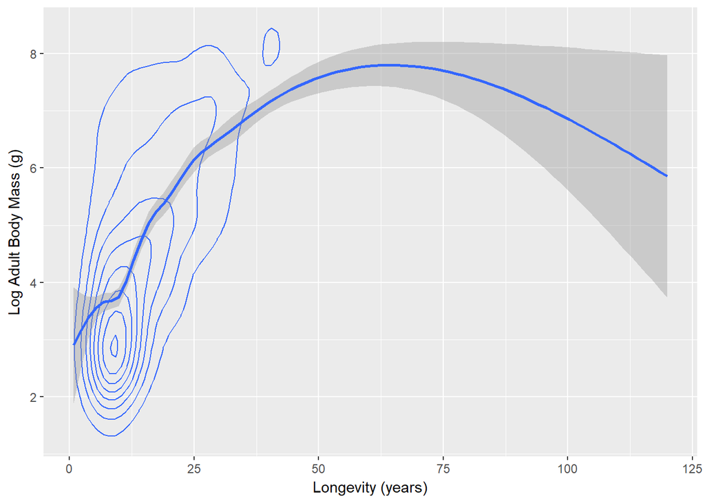

```r
# Relationship between longevity and body size among birds
Amniote %>%
  filter(class!="Mammalia"& class!="Reptilia") %>%
  ggplot(aes(x=maximum_longevity_y, y=log(adult_body_mass_g))) +
  geom_density2d()+ #Too many orders to separate by color
  stat_smooth() +
  ylab("Log Adult Body Mass (g)") +
  xlab("Longevity (years)")
```

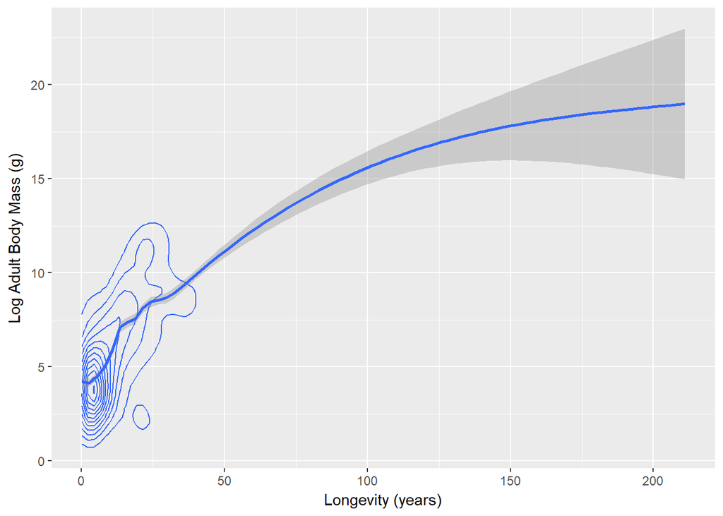

```r
# Relationship between longevity and body size among mammals
Amniote %>%
  filter(class!="Aves"& class!="Reptilia") %>%
  ggplot(aes(x=maximum_longevity_y, y=log(adult_body_mass_g))) +
  geom_density2d()+ #Too many orders to separate by color
  stat_smooth() +
  ylab("Log Adult Body Mass (g)") +
  xlab("Longevity (years)")
```

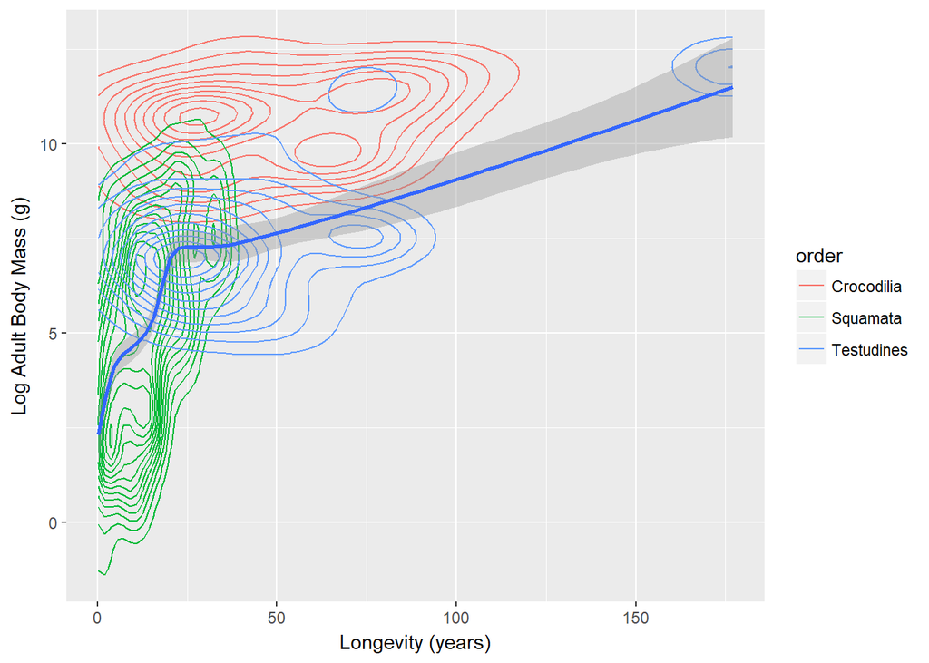

```r
# Relationship between longevity and body size among reptiles
Amniote %>%
  filter(class!="Aves"& class!="Mammalia") %>%
  ggplot(aes(x=maximum_longevity_y, y=log(adult_body_mass_g))) +
  geom_density2d(aes(colour=order))+
  stat_smooth() +
  ylab("Log Adult Body Mass (g)") +
  xlab("Longevity (years)")
```

### Correlation between female body size (in log base e) with respect to egg mass:

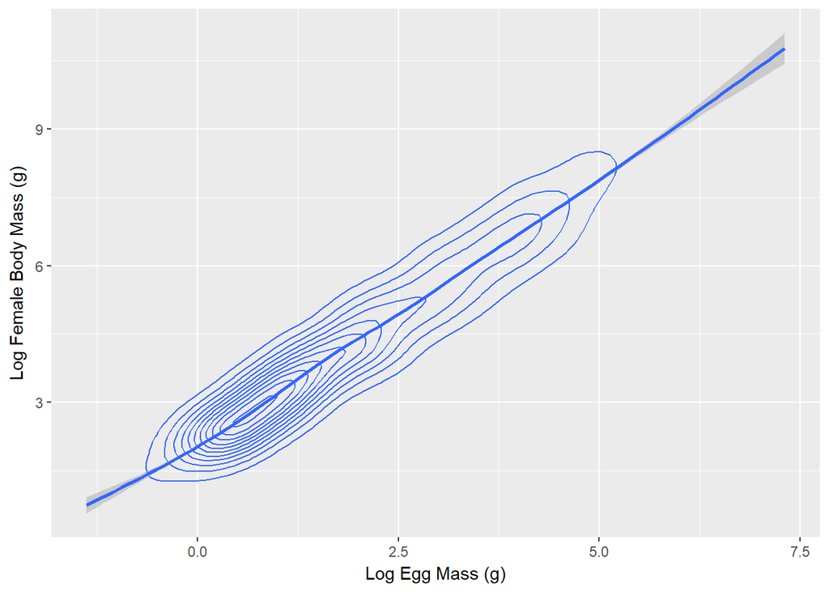

```r
# Relationship between female body size and egg mass among birds
Amniote %>%
  filter(class!="Mammalia", class!="Reptilia") %>%
  ggplot(aes(x=log(egg_mass_g), y=log(female_body_mass_g))) +
  geom_density2d()+ #Impossible to do colors here - too many orders
  stat_smooth() +
  ylab("Log Female Body Mass (g)") +
  xlab("Log Egg Mass (g)")
```

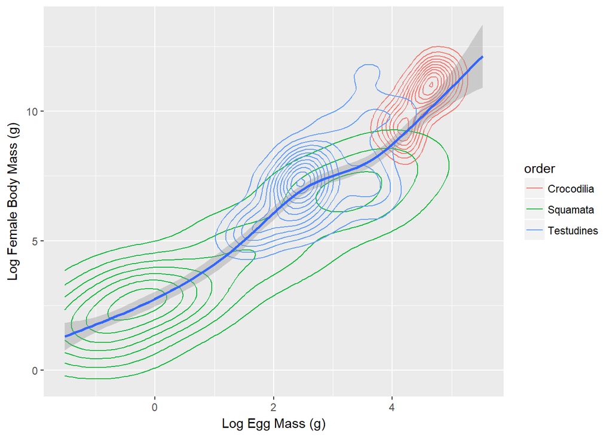

```r
# Relationship between female body size and egg mass among reptiles
Amniote %>%
  filter(class!="Mammalia", class!="Aves") %>%
  ggplot(aes(x=log(egg_mass_g), y=log(female_body_mass_g))) +
  geom_density2d(aes(colour=order))+
  stat_smooth() +
  ylab("Log Female Body Mass (g)") +
  xlab("Log Egg Mass (g)")
```

### Correlation between female maturation with respect to egg mass:

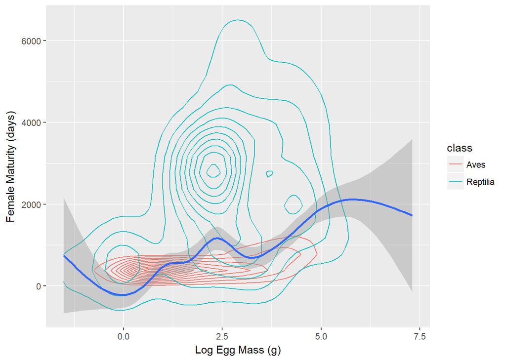

```r
# Relationship between female maturationin days and egg mass among birds and reptiles
Amniote %>%
  filter(class!="Mammalia") %>%
  ggplot(aes(x=log(egg_mass_g), y=female_maturity_d)) +
  geom_density2d(aes(colour=class))+
  stat_smooth() +
  ylab("Female Maturity (days)") +
  xlab("Log Egg Mass (g)")
```